# Project 4: Exploring probability

Tim Hagemeister

24 October, 2019

# Introduction

In this lab, we’ll be investigating the important probability distributions we’ve studied so far in calss. As we’ve seen in lecture, the distributions are easy to use in R. But, deciding which distributions are appropriate is much more interesting.

## Tools and Distros

The distributions we’ll use for this lab are:

- The Binomial Distribution
- The Poisson Distribution
- The Geometric Distribution
- The Uniform Distribution
- The Normal Distribution

## What do we need for each Distribution

**1) Binomial:**

- Only two possible outcomes: Success or fail
- Fixed number of trials, n, decided in advance
- The proibability of success is constant, i.e. never chances
- Each trial must be independent

**2) Poisson:**

- Events happen at a constant average rate (Lambda)
- All occurances are independnt of each other
- The chance of an event occuring is proportional tot he width of the interval (time or space)

**3) Geometric:**

- Only two possible outcomes: Success or fail
- Fixed number of trials, n, decided in advance
- The proibability of success is constant, i.e. never chances
- Each trial must be independent
- *Geometric variables have infinite support*

**4) Uniform Distribution:**

- Infinite, uncountable outcomes
- Probability is tha area under the curve
- ranges from A to B

**5) Normal Distribution:**

- Tails never touch, theres a proability all along the number line
- symmetric about the center, $\mu$, its mean/expected value

# Part 1:

## Using The Distros

This lab presents you with 5 scenarios, each with a question about the data. For each, you’ll need to adress the following:

1. Which distribution (if any!) can be used to answer the question.
2. A discussion of why the properties/requirements of the distribution are satisfied (for example, binomial RVs must satistfy four criteria described in Lec 13).
3. The expected value, variance, and standard deviation for the distro, and a brief explanation of what they mean. You might need to consult the book or the internet (like Wikipedia!) for this.
4. A plot of the distribution.
5. The probability in question. Here, you’ll use the appropriate pdf or cdf. Include a brief explanation of how you computed the probability and what it means.
6. A discussion about whether the event in question is “unusual”. The expected value and variance should feature prominently in this discussion. You may use, as a rule of thumb, that observations which are more than two standard deviations away from the expected value are “unusual”. The graph of the distribution could also be a good reference…
7. If the scenario doesn’t match any of the probability distributions we’ve learned (binomial, geometric, or poisson), then write a brief explanation of why not.

## The Scenarios

In this section, your scenarios are described. You should structure your report accorgingly. For each scenario, write a paragraph that addresses the considerations listed above. As always, use clean formatting, tight grammar, and crisp technical writing.

1. A machine that produces a special type of transistor (a component of computers) has a 2% defective rate. The production is considered a random process where each transistor is independent of the others. You are performing quality control, and investigate the transistors made by the machine until you find a defective one. What’s the probability that you have to look at more than 20 transistors before you find the first defect?
   - **Rational:** We know that this distribution has to be a geometric distribution, This is becasue there are 1) only two possible outcomes (defect or no defect), Fixed number of trials (20 transistors before we find the first defect), The probability of success is constant (98% sucess or 2% fail), Each trial is independent (true), and there is an infinite support (it could be that there is no failure at all).
   - **Method:** When running the Geometric distribution, we need to pick the number 20, this is because it will give us 20 good resistors with the chance of one over 20 being a defective transistor.
   - **Answer:** With this established, there is a 65.4% chance that the quality control officer will see $20th$ transistors that are good and see a defect on one after that.
   - **Analysis**:
   - Expected Value: Since we are observing a Geometric distribution, to find the expected value we would have to use the equation $E[X] = (1-p)/p$. We observe that the following distribution has a expected value of: 49, since we used the equation $E[X] = (1-p)/p$, we are calculating the expected number of fails before the first sucess. This means that in the long run, the expected number of fails before the first success would be 49
   - Variance: To find the variance of a geomteric random variable we would use the equation $Var[X] = (1-p)/p^2$. We oberve that the following distribution has a variance of 2450.
   - Standard Deviation: To find the standard deviation we would need to find $\sigma$, to do this we will use the following formula $\sqrt(2450)$ as SD is the Sqare root of the variation. After plugging in the information we have, we get a standard deviation of 49.50. This mean that our values will vary by 49.50 transistors untill we find a broke onetill the first failure.
- The values given in this graph do not seem unusual, although the SD is great, since it is a range the percentage does not seem to be odd.

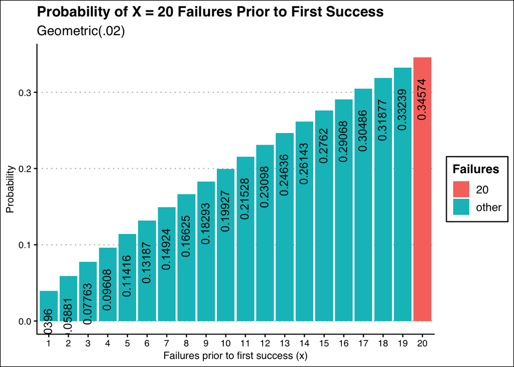

```r
data.frame(x = 1:20, prob = pgeom(1:20, p)) %>%
  mutate(Failures = ifelse(x == n, n, "other")) %>%
ggplot(aes(x = factor(x), y = prob, fill = Failures)) +
  geom_col() +
  geom_text(
    aes(label = round(prob,5), y = prob + 0.0001),
    position = position_dodge(0.9),
    size = 4,
    vjust = 0.4,
    hjust = 1.5,
    angle = 90
    )+
  theme_clean() +
  labs(title = "Probability of X = 20 Failures Prior to First Success",
       subtitle = "Geometric(.02)",
       x = "Failures prior to first success (x)",
       y = "Probability")
```

2. Heights of 10 year olds, regardless of gender, closely follow a normal distribution with mean 55 inches and standard deviation 6 inches. What is the probability that a randomly chosen 10 year old is between 60 and 65 inches?
   - **Rational:** Here we see that this is a normal distribution, This is because there is a infinite number of possibilites, although this does not seem reasonable (there will not be a 10 year old that is 200 inches) it could be possible. Since it says that there is a normal distribution in the height of all 10 year old, we will use a normal distribution function to find the probability. Since we want to find a range of the population we will subtract the larger value from the smaller value to find the area of the distribution between 60 and 65 inches. Since the values can reach infinatly close to 60 and 65, we will include these values in the calculations as well.
   - **Method:** When using the normal distribution function we will be using the CDF as we want to find the area between 65 inches and 60 inches. With a Standard Deviation of 6, and a mean height of 55 inches, the format for all the 10 year olds that have a height under 65 inches will be: $pnorm(65, 55, 6)$. Furthermore we do not want all of the children under 65 inches but only till 60 inches, therefore we need to subtract the area under the distibution of all children under 60: $pnorm(65, 55, 6)$. After these conclusion we know that the final interpretation of the model will be: $pnorm(65, 55, 6)-pnorm(60, 55, 6)$.
   - **Answer:** Therefore we can tell that The probability that a randomyl chosen 10 year old is between 60 and 65 inches is 15.45%
   - **Analysis**:
   - Expected Value: The expected value of a normal distribution is just the mean, which in our case is 55 Inches, and can be seen in our graph below.
   - Variance: The variance of the data is simply the standard deviation (6) squared, which would give us a variation of 36 within our dataset.
   - Standard Deviation: The standard deviation which was given to us in the problem is 6 Inches, this means that 10 year olds within 1 standard deviation should be between 49 and 61 inches tall, This would give you the middle 68.2 percentag of the population.
   - The Graph is not unusual as it is between 1 and 2 standard deviations of the mean, this means that our range is not unusual

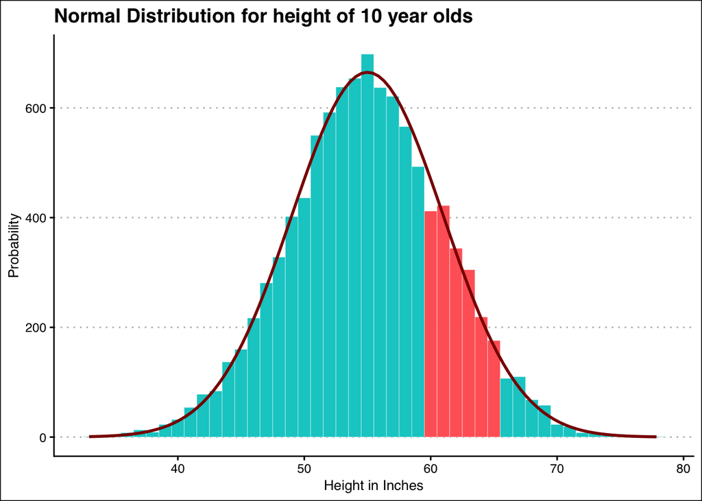

```r
colors <- c(rep("#00CCCC",27), rep("#FF6666",6), rep("#00CCCC",13))


n = 10000
mean = 55
sd = 6
binwidth = 1 # passed to geom_histogram and stat_function
set.seed(1)
df <- data.frame(x = rnorm(n, mean, sd))

ggplot(df, aes(x = x, mean = mean, sd = sd, binwidth = binwidth, n = n), color = group) +
    geom_histogram(binwidth = binwidth,
        colour = "white",
        fill = colors,
        size = 0.1) +
stat_function(fun = function(x) dnorm(x, mean = mean, sd = sd) * n * binwidth,
        color = "darkred", size = 1)+
  theme_clean() +
  labs(title = "Normal Distribution for height of 10 year olds",
       x = "Height in Inches",
       y = "Probability")
```